# EmoPy

6 11 2019

## Architecture

- Convolutional Neural Networks: they pick up on patterns in small parts of an image
- The Time-Delayed 3D-Convolutional Neural Network: instead of using still images as training samples, it uses past images from a series for additional context
- The Convolutional Long Short Term Memory neural net
- Transfer Learning
- ConvolutionalNNDropout

## Datasets

- 2 public datasets
- Microsoft’s [FER2013](https://www.kaggle.com/c/challenges-in-representation-learning-facial-expression-recognition-challenge/data) dataset
- [Extended Cohn-Kanade](http://www.consortium.ri.cmu.edu/ckagree/) dataset

## FER2013

- 35.000 facial expression images for seven emotions

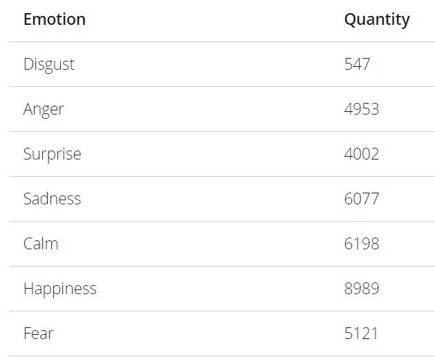

## Extended Cohn-Kanade

- facial expression sequences
- starts with a neutral expression and transitions to a peak emotion

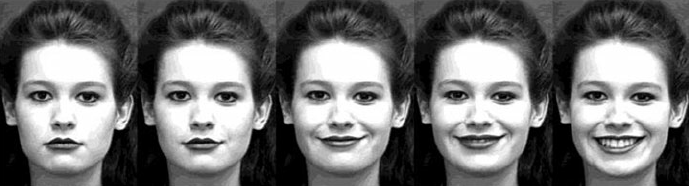

## Training a model

- augmentation techniques to improve our model’s performance
- increasing in the size of existing datasets by applying various transformations to existing images to create new ones

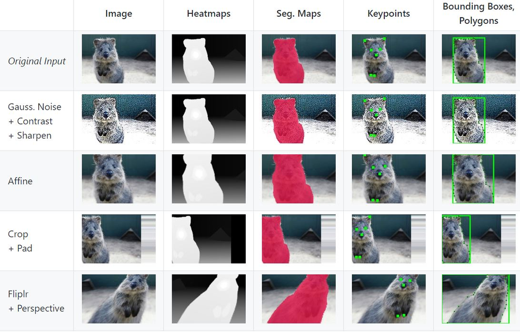

## Testing a model

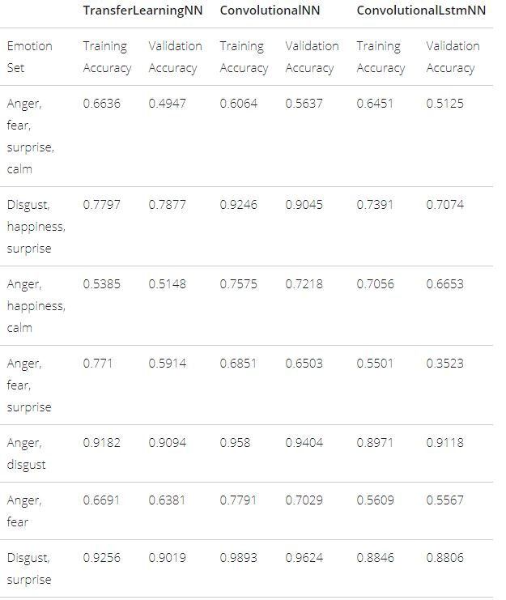

## Project

- from Canvas download new versions of camera.py and fermodel.py
- execute camera.py file and
- emotions variable holds the dictionary of predictions (anger, calm, happines)
- catch predictions to a dataframe:
  - HINTS:
    - before while loop define empty dataframe with columns - df = pd.DataFrame(columns=[“anger”,“calm”,“happines”])
    - in while loop (for part) transform dictionary to dataFrame with pd.DataFrame(dictionary, index=[0])
    - add a new row to existing dataframe with `df1=df1.append(df2)` method
    - after pressing q key, export the dataframe to csv
- analyze data in PowerBI
- check video1.avi